# Variáveis Aleatórias Multidimensionais

Aspectos Gerais

Alexandre Nicolella

nicolella@usp.br

FEARP/USP

2026-03-17

# Variáveis Aleatórias Bidimensionais

# Introdução

## Introdução

- Até o momento: observar apenas uma característica de um experimento -renda, altura, peso, consumo.
- Podemos observar varias caracteristicas ao mesmo tempo: renda e consumo, peso e altura.
- Nesta aula, vamos observar duas características de forma simultânea do mesmo experimento $\epsilon$.

# EXEMPLO

## Jogando Dados 🎲

- O experimento: jogar dois dados não viciados de forma simultânea. Define-se duas variáveis aleatórias: $X$ o número que aparece no dado 1 e $Y$ o número que aparece no dado 2. Assim, temos o seguinte espaço amostral com 36 elementos (6x6):

$$\begin{array}{ccc}
\Omega = { \{(1,1),(1,2),(1,3),...,(6,6)\} }
\end{array}$$

## Jogando Dados 🎲

Como o dado é não viciado cada evento (x,y) tem a mesma probabilidade de ocorrência de 1/36. Assim, a função de **probabilidade bivariada** é:

$$\begin{array}{ccc}
p(x_{i},y_{j})=P(X=x_{i},Y=y_{j})=1/36
\end{array}$$

para i=1,…,6 e j=1,…6.

## Jogando Dados 🎲

Assim como no caso unidimensional pode-se construir um histograma. Com base no exemplo acima, podemos fazer o seguinte histograma tridimensional para o par de dados $X$ e $Y$, ou seja, a distribuição conjunta de $(X,Y)$:

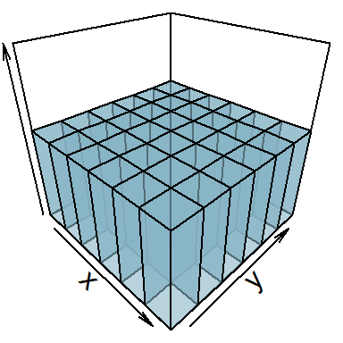

Distribuição conjunta uniforme discreta

## Definindo 📖

Com base nessa ideia podemos fazer a seguinte definição:

**DEFINIÇÃO**

Seja $\epsilon$ um experimento, $\Omega$ um espaço amostral, $X = X(\omega)$ e $Y = Y(\omega)$, para $\omega \in \Omega$, $(X,Y)$ será uma variável aleatória bidimensional (ou vetor aleatório).

## O Vetor Aleatório

- Agora possuímos não mais um espaço unidimensaional $R_{x}$ como anteriormente visto, mas sim **bidimensional**;
- Ou seja, o contradomínio da variável aleatória será $R_{xy}$ e cada resultado $X = X(\omega)$ e $Y = Y(\omega)$ pode ser representado como um ponto $(x,y)$ no plano euclidiano;
- Podemos dividir os resultado de um experimento em dois tipos, os discretos e os contínuos. Vejamos a seguir esses dois tipos resultados.

# Variáveis Aleatórias Discretas

## Introdução

- São variáveis que conseguimos colocar em lista, seja ela finita ou infinita.
- Assim, o vetor (X,Y) será uma variável aleatória discreta bidimensional ou vetor aleatório bidimensional se os valores possíveis puderem ser representados por $(x_{i},y_{i})$, $i=1,...,n,...$; e $j=1,2,...,m,...$
- Como no caso unidimensional, podemos definir a distribuição de probabilidade conjunta de $(X,Y)$

## Definindo 📖

**DEFINIÇÃO**

A cada valor possível da variável aleatória bidimensional $(X,Y)$, $(x_{i},y_{j})$, associamos uma probabilidade $p(x_{i},y_{j})$, $P (X=x_{i},Y=y_{i})$, e irá satisfazer:

1. $p(x_{i},y_{j}) \geq 0$ para todo $(x,y)$
2. $\sum_{i} \sum_{j} p(x_{i},y_{j})=1$

## Definindo 📖

- Podemos definir agora a função distribuição conjunto, ou seja:

**DEFINIÇÃO**

**Função de probabilidade conjunta de (X,Y)** (ou bivariada):

$p(x_{i},y_{j})= P(X=x_{i},Y=y_{j})$ para $-\infty < x_{i}< \infty$ e $-\infty < y_{j}< \infty$

**Distribuição de probabilidade conjunta de (X,Y)** (ou bivariada): $[x_{i},y_{j},p(x_{i},y_{j})]$

- Para fixarmos as definições apresentadas acimas, e colocarmos os conceitos em prática, vamos realizar dois exemplos.

# EXEMPLO

## Jogando Dados 🎲

**EXEMPLO**

Considere o experimento de jogar dois dados simultaneamente.

Considere a função de distribuição conjunta e calcule a probabilidade conjunta de $P(5\leq X \leq 6, 1 \leq Y \leq 2)$

**RESPOSTA**

$$\begin{aligned}
P(5\leq X \leq 6, 1 \leq Y \leq 2) &= p(5,1)+p(5,2) + p(6,1)+p(6,2) \\
&= 4 \cdot \frac{1}{36} = \frac{1}{9}
\end{aligned}$$

# EXEMPLO

## Caixa de Supermercado 🛒

Um supermercado possui três caixas operando. Dois consumidores chegam aos caixas, que estão vazios, em momentos distintos do tempo. Cada consumidor escolhe um caixa de forma aleatória e independente do outro. Seja X o número de consumidores que escolhem o caixa 1 e Y os que escolhem o caixa 2. Qual a distribuição conjunta de X e Y?

**RESPOSTA**

O espaço amostral do experimento será dado pelo par ordenado $\{ i,j \}$, onde o primeiro consumidor escolhe o caixa $i$ e o segundo escolhe $j$, tal que $i=1,2,3$ e $j=1,2,3$. Assim, cada ponto amostral tem a mesma probabilidade e o espaço amostral pode ser representado como :

## Caixa de Supermercado 🛒

**EXEMPLO**

**Continuação Resposta:**

$$\Omega = { \{(1,1),(1,2),(1,3),...,(3,3)\} }$$

A distribuição conjunta de X e Y será conforme descrito na tabela abaixo. Para construir essa tabela note que, por exemplo, $P(X=0,Y=0)=P(\{(3,3)\})=1/9$ e que $P(X=0,Y=1)=P(\{(2,3),(3,2)\})=2/9$

| y (cx2) | x=0 (cx1) | x=1 (cx1) | x= 2 (cx1) |
| --- | --- | --- | --- |
| y=0 | 1/9 | 2/9 | 1/9 |
| y=1 | 2/9 | 2/9 | 0 |
| y=2 | 1/9 | 0 | 0 |

# VA Discretas: Graficamente

## BINOMIAL:

- Considere a variável aleatória $(X,Y)$ com distribuição binomial e a probabilidade de sucesso de $X$ é igual a 0.75 e de $Y$ igual a 0.25 com 10 rodadas:

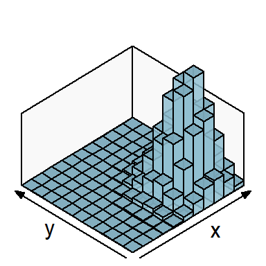

Distribuição conjunta Binomial

## POISSON

- Considere a variável aleatória $(X,Y)$ com distribuição de poisson e o valor esperado de $X$ iual a 7, de $Y$ igual a 4 e a covariância é 3 (a frente veremos esse conceito):

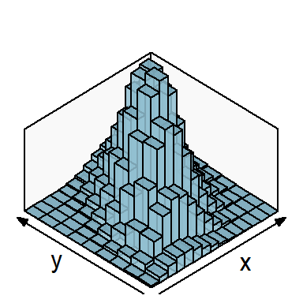

Distribuição conjunta de Poisson

# Variáveis Aleatórias Contínuas

## Introdução

- São variáveis que não conseguimos listar, pois existem infinitos valores entre dois pontos.
- Assim,o vetor $(X,Y)$ será uma variável aleatória contínua se puder tomar todos os valores em algum conjunto não enumerável no plano euclediano

## Definindo 📖

**DEFINIÇÃO**

Sendo $(X,Y)$ variável aleatória contínua bidimensional. A função densidade de probabilidade conjunta, $f(x,y)$, irá satisfazer:

1. $f(x,y) \geq 0$
2. $\iint_{R} f(x,y)dxdy= 1$ se f(x,y)=0 para $(x,y)\notin R \rightarrow \int_{- \infty}^{\infty}\int_{- \infty}^{\infty} f(x,y)=1$

Importante notar que $f(x,y)$ não representa a probabilidade.

## Para um evento qualquer…

Assim para um evento B em $R_{xy}$:

$$\begin{array}{ccc}
P(B)=P\{ [X(\omega),Y(\omega)] \in B \}= P\{\omega | [X(\omega),Y(\omega)] \in B \}
\end{array}$$

Para o caso discreto:
$$\begin{array}{ccc}
P(B)=\sum \sum_{B} p(x_{i},y_{j})
\end{array}$$

Para o caso contínuo:
$$\begin{array}{ccc}
P(B)=\iint_{B}f(x,y)dxdy
\end{array}$$

## Para um evento qualquer…

- Reinterpretando o evento B, análogo ao caso unidimensional, o caso bidimensional o **volume sob a função densidade de probabilidade conjunta representa a probabilidade**.
- Assim, uma probabilidade $P(a \leq X \leq b, c\leq Y \leq d)$ é calculada como:

$$\begin{array}{ccc}
P(a \leq X \leq b, c\leq Y \leq d) = \int_{c}^{d}\int_{a}^{b} f(x,y)dxdy
\end{array}$$

# EXEMPLO

## Partícula no Quadrado ⚛️

**EXEMPLO**

Suponha que uma partícula é aleatoriamente alocada em um quadrado com lados iguais a 1. Assim, se duas áreas de mesma dimensão forem consideradas a partícula tem a mesma probabilidade de estar em qualquer uma das duas áreas. Seja $X$ e $Y$ as coordenadas da localização da partícula. A função de densidade conjunta de $X$ e $Y$ será:

$$\begin{array}{ccc}
f(x,y)=\left\{\begin{matrix} 1,\ 0\ \leq x \leq 1, \ 0\ \leq y \leq 1
\\
0,\ caso\ contrário
\end{matrix}\right.
\end{array}$$

## Partícula no Quadrado ⚛️

**EXEMPLO**

1. Esboce a função densidade de probabilidade conjunta
2. Encontre $P(0 \leq X \leq 0.2, 0\leq Y \leq 0.4)$

**RESPOSTA**

Ver figura abaixo.
$$\begin{array}{ccc}
P(0 \leq X \leq 0.2,0 \leq Y \leq 0.4)= \int_{0}^{0.4}\int_{0}^{0.2}f(x,y)dxdy
\\
=\int_{0}^{0.4}\int_{0}^{0.2}1dxdy=\int_{0}^{0.4}(\int_{0}^{0.2}1dx)dy=\int_{0}^{0.4}(x\Big|_{0}^{0.2})dy
\\
=(0.2-0)\int_{0}^{0.4}1dy=(0.2-0).(y\Big|_{0}^{0.4})=(0.2-0)(0.4-0)=0.08
\\
P(0 \leq X \leq 0.2,0 \leq Y \leq 0.4)=0.08
\end{array}$$

## Partícula no Quadrado ⚛️

**EXEMPLO**

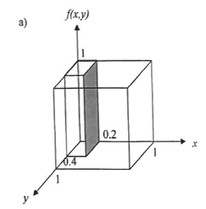

# VA Contínuas: Graficamente

## NORMAL BIVARIADA

Considere a variável aleatória $(X,Y)$ com distribuição normal bivariada com a esperança de $X$ igual a 10, de $Y$ igual a 4, o desvio-padrões iguais a 3 e 2 respectivamente. Aqui consideremaos a correlação de 0.7 (veremos mais a frente esse conceito).

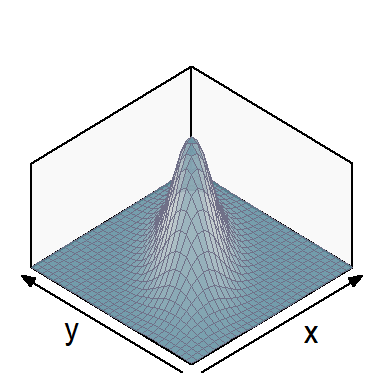

Distribuição conjunta normal bivariada

## NORMAL BIVARIADA PADRÃO

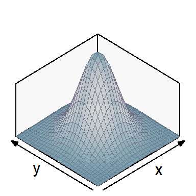

Distribuição conjunta normal padrão bivariada

# Função Distribuição Acumulada

# Caso Discreto

## Definindo 📖

- A distinção entre variável aleatória conjunta contínua e discreta pode ser feita em termos de sua função distribuição conjunta acumulada.

**DEFINIÇÃO**

A função distribuição conjunta acumulada, $F$, da variável aleatória bidimensional $(X,Y)$ é definida por:
$$\begin{array}{ccc}
F(x,y)= P(X \leq x, Y \leq y) \ para \ -\infty < x_{i} < \infty \ e \ -\infty < y_{i} < \infty
\end{array}$$

## Definindo 📖

Sejam $X$ e $Y$ duas variáveis aleatórias discretas com função distribuição conjunta $F(x,y)$, a função distribuição conjunta acumulada de $X$ e $Y$ será:

$$\begin{array}{ccc}
F(x,y)=\sum_{f1=- \infty }^{x} \sum_{f2=- \infty }^{y}p(t_{1},t_{2})
\end{array}$$

Retomando os exemplos anteriores temos as seguintes funções de distribuição conjunta acumuladas discretas:

# EXEMPLO

## Jogando Dados 🎲

**EXEMPLO**

Para o caso dos dois dados apresentados anteriormente temos que:

$$\begin{array}{ccc}
F(2,3)=P(X \leq 2, Y \leq 3)=p(1,1)+p(1,2)+p(1,3)+ \\
p(2,1)+p(2,2)+p(2,3)
\end{array}$$

$$F(2,3)=P(X\leq 2, Y \leq 3)=6/36=1/6$$

## Jogando Dados 🎲

- O Gráfico da função probabilidade acumulada conjunta do exemplo dos dados será:

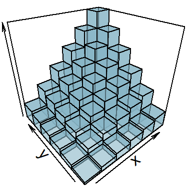

Distribuição acumulada conjunta uniforme discreta

## Caixa de Supermercado 🛒

**EXEMPLO**

Para o exemplo anterior (caixa do supermercado) encontre F(-1,2) e F(1.5,2)

$$F(-1,2) = P(X \leq -1, Y \leq 2)= P(\emptyset)=0$$

*Note que é impossível no exemplo do caixa o valor assumir -1, portanto, temos a probabilidade de um conjunto vazio, que será zero.

$$\begin{array}{ccc}
F(1.5,2) = P(X \leq 1.5, Y \leq 2)= p(0,0)+p(0,1)+p(0,2)+p(1,0)
\\
+p(1,1)+p(1,2)=8/9
\end{array}$$

# FDA Discreta: Graficamente

## BINOMIAL

Considere a variável aleatória $(X,Y)$ com distribuição binomial e a probabilidade de sucesso de $X$ é igual a 0.75 e de $Y$ igual a 0.25 com 10 rodadas, sua função distribuição acumulada será:

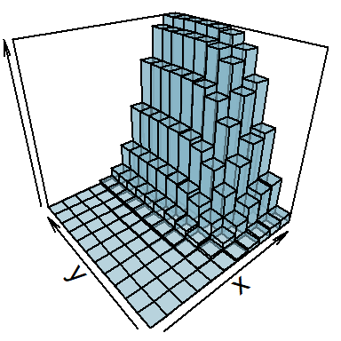

Distribuição conjunta Binomial

## POISSON

Considere a variável aleatória $(X,Y)$ com distribuição de poisson e o valor esperado de $X$ iual a 7, de $Y$ igual a 4 e a covariância é 3 (a frente veremos esse conceito). Assim a função distribuição acumulada será:

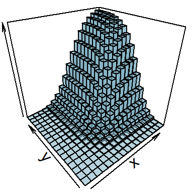

Distribuição conjunta de Poisson

# FDA: Caso Contínuo

## Definindo 📖

- Sejam X e Y duas variáveis aleatórias contínuas com função distribuição conjunta $F(x,y)$.
- Se existir uma função densidade de probabilidade conjunta $f(x,y)$ não negativa, assim a **função distribuição acumulada conjunta de X e Y** será:

$$\begin{array}{ccc}
F(x,y) = \int_{-\infty}^{x}\int_{- \infty}^{y} f(t_{1},t_{2})dt_{1}dt_{2} \\
\end{array}$$

para $-\infty < x_{i} < \infty$ e $-\infty < y_{i} < \infty$

# EXEMPLO

## Partícula no Quadrado ⚛️

**EXEMPLO**

Para o exemplo anterior da partícula, encontre F(0.4, 0.4):

## Definindo…mais um pouco 📖

**TEOREMA**

Seja $X$ e $Y$ duas variáveis aleatórias contínuas com função distribuição conjunta $F(x,y)$ então:

$$\begin{array}{ccc}
a) \ F(- \infty, - \infty )= F(- \infty, y )= F(x, - \infty )=0 \\
\end{array}$$

$$\begin{array}{ccc}
b) \ F(\infty, \infty ) = 1
\end{array}$$

No caso bivariado tem-se:
$$\begin{array}{ccc}
f(x,y) = \frac{\partial^{2}F(x,y) }{\partial x \partial y}
\end{array}$$

# FDA Contínua: Graficamente

## NORMAL BIVARIADA

Considere a variável aleatória $(X,Y)$ com distribuição normal bivariada com a esperança de $X$ igual a 10, de $Y$ igual a 4, o desvio-padrões iguais a 3 e 2 respectivamente. Aqui consideremaos a correlação de 0.7 (veremos mais a frente esse conceito). Assim a função distribuição acumulada conjunta terá o seguinte formato:

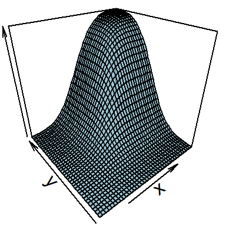

Distribuição acumulada conjunta normal

## NORMAL BIVARIADA PADRÃO:

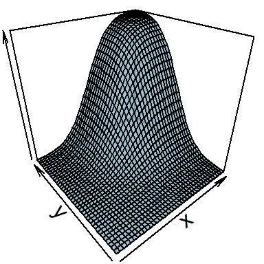

Distribuição acumulada conjunta normal padrão